# Viewership Trends in *Game of Thrones*

Author

Mikita Silivestrau

## AI assistance disclosure

This report uses AI assistance (GPT-5.5 Thinking) for structuring the report and preparing R code for tables and plots.

## Brief description

*Game of Thrones* is an American fantasy drama television series created by David Benioff and D. B. Weiss for HBO. It is based on George R. R. Martin’s book series *A Song of Ice and Fire*. The series premiered in 2011 and concluded in 2019 after eight seasons.

## Image

[figure not shown]

Title card of *Game of Thrones*. Source: Wikipedia/Wikimedia.

## Data

The table below shows the number of episodes and the average U.S. viewership for each season, in millions of viewers. Values were taken from the season overview table on Wikipedia.

| Season | Episodes | Avg. viewers (M) | Change (M) | Change (%) |
| --- | --- | --- | --- | --- |
| 1 | 10 | 2.52 | NA | NA |
| 2 | 10 | 3.80 | 1.28 | 50.79 |
| 3 | 10 | 4.97 | 1.17 | 30.79 |
| 4 | 10 | 6.84 | 1.87 | 37.63 |
| 5 | 10 | 6.88 | 0.04 | 0.58 |
| 6 | 10 | 7.69 | 0.81 | 11.77 |
| 7 | 7 | 10.26 | 2.57 | 33.42 |
| 8 | 6 | 11.99 | 1.73 | 16.86 |

## Basic statistics

| Statistic | Value |
| --- | --- |
| Min | 2.52 M |
| Max | 11.99 M |
| Mean | 6.87 M |
| Season 1 → 8 (absolute) | +9.47 M |
| Season 1 → 8 (percent) | +376% |

Viewership grew every season. Season 1 averaged 2.52 million U.S. viewers; by season 8 the average was 11.99 million — a 4.8× increase over the run of the show.

The biggest jump between consecutive seasons was from season 6 to season 7 (+2.57 million); the smallest was from season 4 to season 5 (+0.04 million).

## Viewership over time

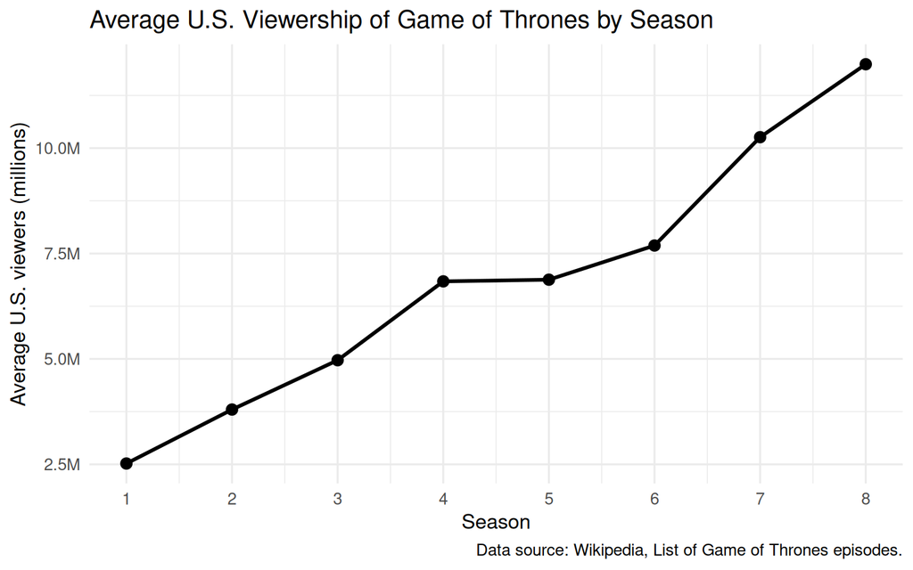

## Season-to-season changes in viewership

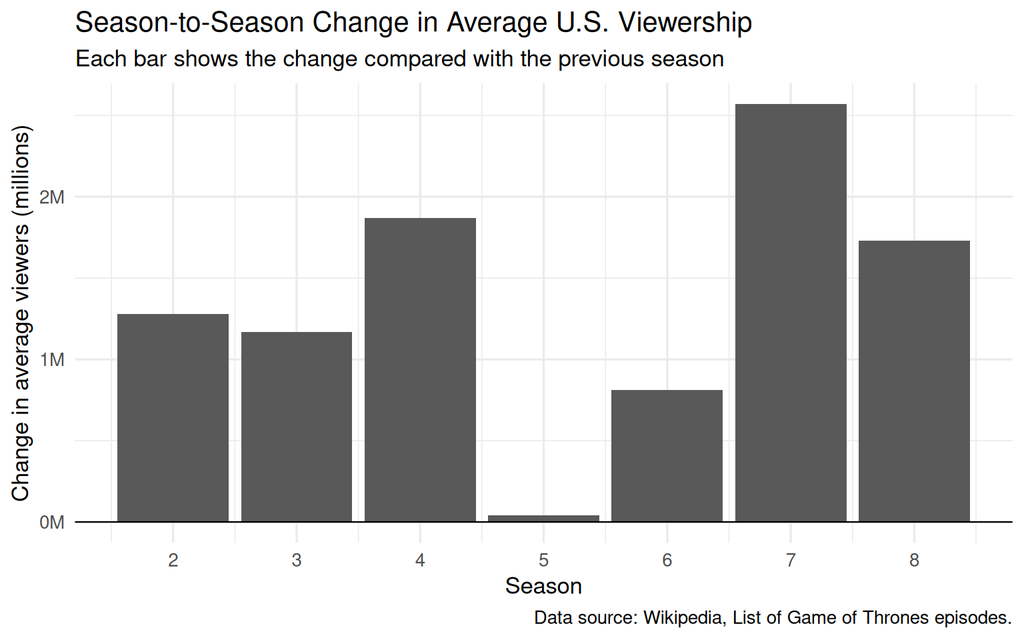

## References

Wikipedia contributors. “Game of Thrones.” *Wikipedia, The Free Encyclopedia*.  
Wikipedia contributors. “List of Game of Thrones episodes.” *Wikipedia, The Free Encyclopedia*.  
Image source: Wikipedia/Wikimedia, *Game of Thrones* title card.